# HW 2

## **IE 582 Statistical Learning for Data Mining**

## **Homework 2**

## **Task 1 – Dimensionality Reduction**

*a) Apply PCA to reduce the number of dimensions to one and visualize the instances on a scatter plot. Note that the scatter plot will show the observation number versus the observed value (as we have a single feature to represent the instance).*

Principal Component Analysis (PCA) is a linear dimensionality reduction technique that can be utilized for extracting information from a high-dimensional space by projecting it into a lower-dimensional sub-space. It tries to preserve the essential parts that have more variation of the data and remove the non-essential parts with fewer variation.

One important thing to note about PCA is that it is an Unsupervised dimensionality reduction technique, we can cluster the similar data points based on the feature correlation between them without any supervision (or labels). For more information you can visit the following [article](https://www.datacamp.com/community/tutorials/principal-component-analysis-in-python).

```python
import pandas as pd
import numpy as np
import matplotlib.pyplot as plt
import seaborn as sns
%matplotlib inline
data = pd.read_csv('/Users/enes/Documents/IE 582/HW 2/IE582_Fall21_HW2_q1_data.csv')
```

```python
print('Dataset dimensions:',data.shape)
data.head()
```

```
Dataset dimensions: (198, 3)
```

|  | X1 | X2 | class |
| --- | --- | --- | --- |
| 0 | 0.569483 | 0.822003 | a |
| 1 | 0.411469 | 0.911424 | a |
| 2 | 0.417385 | -0.908730 | a |
| 3 | -0.791828 | 0.610745 | a |
| 4 | -0.806777 | -0.590857 | a |

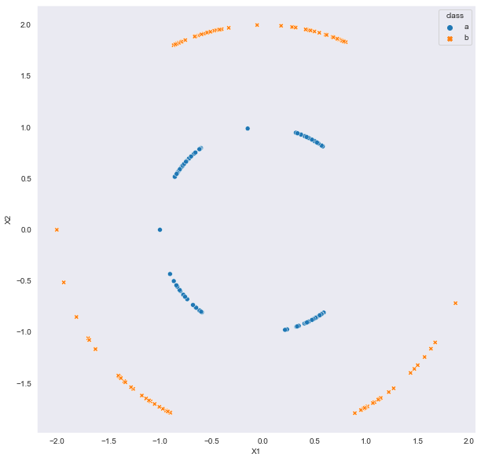

```python
sns.set_style("dark")
plt.figure(figsize=(10,10))
sns.scatterplot(x="X1",y="X2", hue="class", style="class", data=data);
```

I will use the sklearn library to import the PCA module, and in the PCA method, I will pass the number of components (n_components=1) and finally call fit_transform on the aggregate data.

```python
from sklearn.decomposition import PCA
pca = PCA(n_components=1)
x=data.iloc[:,:2]
pca_applied = pca.fit_transform(x)
pca_data = pd.DataFrame(data = pca_applied, columns = ['X(PCA)'])
pca_data.head()
```

|  | X(PCA) |
| --- | --- |
| 0 | 0.722069 |
| 1 | 0.811347 |
| 2 | -1.008801 |
| 3 | 0.509578 |
| 4 | -0.692037 |

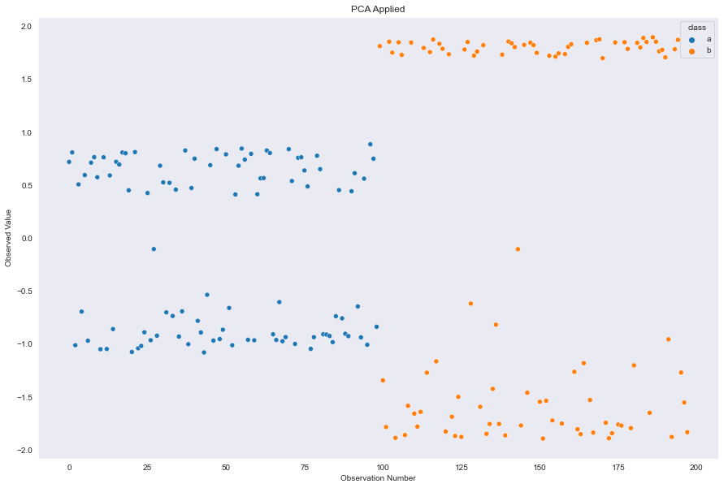

```python
pca_data["class"] = data['class']
pca_data["observation_no"] = pca_data.index
plt.figure(figsize=(15,10))
sns.scatterplot(x = "observation_no", y = "X(PCA)", hue="class", data=pca_data)
plt.title('PCA Applied')
plt.xlabel('Observation Number')
plt.ylabel('Observed Value')
```

*b) Apply MDS to reduce the number of dimensions to one and visualize the instances on a scatter plot as in part (a). Use at least two different similarity measure.*

MDS maps points residing in a higher-dimensional space to a lower-dimensional space while preserving the distances between those points as much as possible. Because of this, the pairwise distances between points in the lower-dimensional space are matched closely to their actual distances.For more information you can visit the following [article](https://stackabuse.com/guide-to-multidimensional-scaling-in-python-with-scikit-learn/).

```python
from sklearn.manifold import MDS
from sklearn.metrics.pairwise import manhattan_distances, euclidean_distances
from matplotlib.offsetbox import OffsetImage, AnnotationBbox
```

```python
mds = MDS(n_components=1,dissimilarity="euclidean")
x=data.iloc[:,:2]
mds_applied = mds.fit_transform(x)
mds_data = pd.DataFrame(data = mds_applied, columns = ['X(MDS)'])
mds_data.head()
```

|  | X(MDS) |
| --- | --- |
| 0 | -0.797207 |
| 1 | -0.849292 |
| 2 | 1.079003 |
| 3 | -0.343768 |
| 4 | 0.554290 |

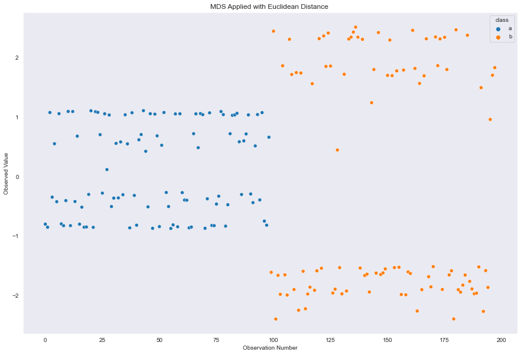

```python
mds_data["class"] = data['class']
mds_data["observation_no"] = mds_data.index
plt.figure(figsize=(15,10))
sns.scatterplot(x = "observation_no", y = "X(MDS)", hue="class", data=mds_data)
plt.title('MDS Applied with Euclidean Distance ')
plt.xlabel('Observation Number')
plt.ylabel('Observed Value')
```

```python
from sklearn.neighbors import DistanceMetric
dist = DistanceMetric.get_metric('manhattan')
x=data.iloc[:,:2]
dist_matrix = dist.pairwise(x)
mds = MDS(n_components=1, dissimilarity='precomputed')
mds2 = mds.fit_transform(dist_matrix)
mds_data2 = pd.DataFrame(data = mds2, columns = ['X(MDS2)'])
mds_data2.head()
```

|  | X(MDS2) |
| --- | --- |
| 0 | -0.775684 |
| 1 | -0.856409 |
| 2 | 1.340017 |
| 3 | -0.335425 |
| 4 | 0.748380 |

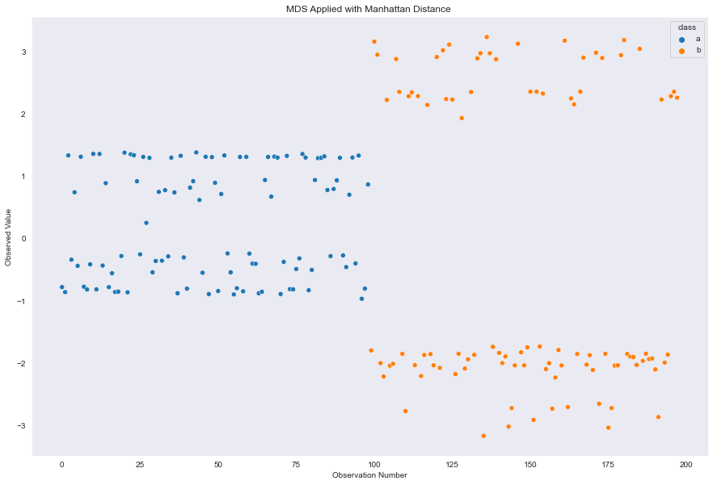

```python
mds_data2["class"] = data['class']
mds_data2["observation_no"] = mds_data2.index
plt.figure(figsize=(15,10))
sns.scatterplot(x = "observation_no", y = "X(MDS2)", hue="class", data=mds_data2)
plt.title('MDS Applied with Manhattan Distance ')
plt.xlabel('Observation Number')
plt.ylabel('Observed Value')
```

*c) On a 2D scatter plot, one can observe how two observations from two classes are different.*

1. *What is your conclusion when you use PCA results in single dimension (your results from part a)?*
2. *What is your conclusion when you use MDS results in single dimension (your results from part b)? Compare the results from different similarity measures used in part (b)*
3. *Compare MDS results with PCA. What is your conclusion?*

*d) Suppose, you are not satisfied with your dimensionality reduction scheme in part (a). Add the following columns to your data, X1^2, X2^2, X1×X2 (three columns as functions of your original variables) and apply PCA. Comment on the PCA results (i.e. what are the eigenvalues? What do they refer to?).*

```python
data2 = data
data2["X1^2"] = data2["X1"]*data2["X1"]
data2["X2^2"] = data2["X2"]*data2["X2"]
data2["X1xX2"] = data2["X1"]*data2["X2"]
data2.head()
```

|  | X1 | X2 | class | X1^2 | X2^2 | X1xX2 |
| --- | --- | --- | --- | --- | --- | --- |
| 0 | 0.569483 | 0.822003 | a | 0.324311 | 0.675689 | 0.468117 |
| 1 | 0.411469 | 0.911424 | a | 0.169307 | 0.830693 | 0.375023 |
| 2 | 0.417385 | -0.908730 | a | 0.174210 | 0.825790 | -0.379290 |
| 3 | -0.791828 | 0.610745 | a | 0.626991 | 0.373009 | -0.483604 |
| 4 | -0.806777 | -0.590857 | a | 0.650889 | 0.349111 | 0.476689 |

```python
pca = PCA(n_components=1)
x=data[['X1', 'X2','X1^2', 'X2^2', 'X1xX2']]
pca_applied = pca.fit_transform(x)
pca_data = pd.DataFrame(data = pca_applied, columns = ['X(PCA)'])
pca_data.head()
```

|  | X(PCA) |
| --- | --- |
| 0 | -0.139714 |
| 1 | 0.051931 |
| 2 | -1.190015 |
| 3 | -0.581394 |
| 4 | -1.534138 |

[figure not shown]

```python
mds_data["class"] = data['class']
mds_data["observation_no"] = mds_data.index
plt.figure(figsize=(15,10))
sns.scatterplot(x = "observation_no", y = "X(MDS)", hue="class", data=mds_data)
plt.title('MDS Applied with Euclidean Distance ')
plt.xlabel('Observation Number')
plt.ylabel('Observed Value')
```

## **Task 2 – Reconstructing Turkey Map**

*Please download the intercity distance information from Karayolları Genel Müdürlüğü’s website from this [link](https://www.kgm.gov.tr/SiteCollectionDocuments/KGMdocuments/Root/Uzakliklar/ilmesafe.xls).*

*Suppose we apply MDS to this data to distance matrix to obtain latent variables in 2D dimensional space. Represent the new feature space on a 2D plot. You are expected to label each data point with the respective city’s name. This plot should be similar to Turkey map. Are there any unusual observations? If yes, comment on your findings.*

```python
dataset=pd.read_excel('/Users/enes/Documents/IE 582/HW 2/ilmesafe.xls', header=2)
dataset_yedek=dataset
dataset=dataset.fillna(0)
#we don't need "İL PLAKA NO" so i droped it
dataset.head(10)
```

|  | İL PLAKA NO | İL ADI | ADANA | ADIYAMAN | AFYONKARAHİSAR | AĞRI | AMASYA | ANKARA | ANTALYA | ARTVİN | ... | BATMAN | ŞIRNAK | BARTIN | ARDAHAN | IĞDIR | YALOVA | KARABÜK | KİLİS | OSMANİYE | DÜZCE |
| --- | --- | --- | --- | --- | --- | --- | --- | --- | --- | --- | --- | --- | --- | --- | --- | --- | --- | --- | --- | --- | --- |
| 0 | 1 | ADANA | 0.0 | 335.0 | 575.0 | 966.0 | 603.0 | 567.0 | 535.0 | 1035.0 | ... | 621.0 | 709.0 | 782.0 | 1042.0 | 1066.0 | 899.0 | 714.0 | 246.0 | 87.0 | 735.0 |
| 1 | 2 | ADIYAMAN | 335.0 | 0.0 | 910.0 | 648.0 | 632.0 | 814.0 | 870.0 | 751.0 | ... | 303.0 | 471.0 | 1023.0 | 758.0 | 748.0 | 1147.0 | 955.0 | 210.0 | 248.0 | 976.0 |
| 2 | 3 | AFYONKARAHİSAR | 575.0 | 910.0 | 0.0 | 1318.0 | 597.0 | 300.0 | 290.0 | 1243.0 | ... | 1196.0 | 1284.0 | 515.0 | 1351.0 | 1461.0 | 338.0 | 447.0 | 821.0 | 662.0 | 375.0 |
| 3 | 4 | AĞRI | 966.0 | 648.0 | 1318.0 | 0.0 | 738.0 | 1141.0 | 1428.0 | 396.0 | ... | 369.0 | 430.0 | 1175.0 | 310.0 | 143.0 | 1363.0 | 1106.0 | 814.0 | 879.0 | 1192.0 |
| 4 | 5 | AMASYA | 603.0 | 632.0 | 597.0 | 736.0 | 0.0 | 413.0 | 825.0 | 695.0 | ... | 796.0 | 982.0 | 437.0 | 783.0 | 881.0 | 625.0 | 368.0 | 639.0 | 608.0 | 454.0 |
| 5 | 6 | ANKARA | 492.0 | 742.0 | 256.0 | 1054.0 | 333.0 | 0.0 | 542.0 | 979.0 | ... | 1001.0 | 1147.0 | 283.0 | 1087.0 | 1197.0 | 407.0 | 215.0 | 710.0 | 579.0 | 236.0 |
| 6 | 7 | ANTALYA | 535.0 | 870.0 | 291.0 | 1428.0 | 825.0 | 543.0 | 0.0 | 1466.0 | ... | 1156.0 | 1244.0 | 801.0 | 1473.0 | 1571.0 | 600.0 | 733.0 | 781.0 | 622.0 | 637.0 |
| 7 | 8 | ARTVİN | 1035.0 | 751.0 | 1243.0 | 396.0 | 693.0 | 979.0 | 1466.0 | 0.0 | ... | 597.0 | 756.0 | 1039.0 | 116.0 | 341.0 | 1254.0 | 970.0 | 917.0 | 948.0 | 1083.0 |
| 8 | 9 | AYDIN | 874.0 | 1209.0 | 345.0 | 1640.0 | 938.0 | 597.0 | 339.0 | 1584.0 | ... | 1495.0 | 1583.0 | 856.0 | 1685.0 | 1783.0 | 510.0 | 788.0 | 1120.0 | 961.0 | 671.0 |
| 9 | 10 | BALIKESİR | 903.0 | 1238.0 | 328.0 | 1567.0 | 831.0 | 536.0 | 507.0 | 1460.0 | ... | 1523.0 | 1612.0 | 577.0 | 1568.0 | 1712.0 | 216.0 | 556.0 | 1149.0 | 990.0 | 377.0 |

10 rows × 83 columns

```python
dataset=dataset.drop(columns=['İL PLAKA NO', 'İL ADI'])
dataset=pd.DataFrame(np.tril(dataset) + np.tril(dataset, -1).T)
```

```python
mds = MDS(n_components=2, dissimilarity="precomputed")
dataset_t=mds.fit_transform(dataset)
dataset_t=pd.DataFrame(dataset_t)
```

```python
dataset_t=dataset_t.set_axis(['MDS 1','MDS 2'], axis=1)
dataset_t['İL ADI']=dataset_yedek['İL ADI']
dataset_t.head(10)
```

|  | MDS 1 | MDS 2 | İL ADI |
| --- | --- | --- | --- |
| 0 | 17.095821 | -376.895711 | ADANA |
| 1 | -322.611224 | -413.117015 | ADIYAMAN |
| 2 | 493.999239 | -28.874721 | AFYONKARAHİSAR |
| 3 | -813.171573 | -20.784884 | AĞRI |
| 4 | -72.516912 | 187.948598 | AMASYA |
| 5 | 244.862391 | 97.736941 | ANKARA |
| 6 | 559.282390 | -316.307906 | ANTALYA |
| 7 | -732.002665 | 264.855857 | ARTVİN |
| 8 | 833.967372 | -132.691661 | AYDIN |
| 9 | 761.541549 | 163.748285 | BALIKESİR |

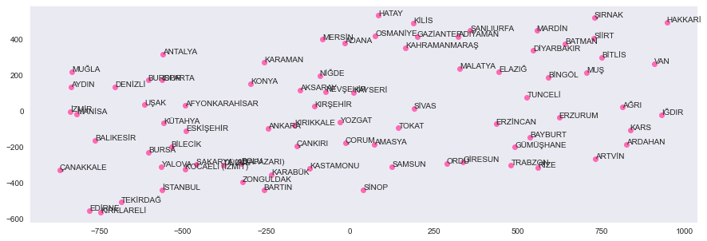

```python
plt.figure(figsize=(15,5))
plt.scatter(-dataset_t["MDS 1"], -dataset_t["MDS 2"], color = 'hotpink')
for txt, x, y in zip(dataset_t["İL ADI"], dataset_t["MDS 1"], dataset_t["MDS 2"]):
    plt.annotate(txt, (-x,-y))
plt.show()
```

## **Task 3 – Dimensionality reduction for time series data**

The conference paper by Liu et al. (2009) starts with the following statement: “Gestures have recently become attractive for spontaneous interaction with consumer electronics and mobile devices in the context of pervasive computing”. The aim is to provide efficient personalized gesture recognition on wide range of devices.

The dataset is provided in the following [link](https://drive.google.com/drive/u/1/folders/13553neknux7U8why55KM1WrjgkA9IJKm)

Note that there are separate files for each axis and each row corresponds to one gesture in the files. First column has the class information. The information between second and last column is the time ordered observations in the corresponding axis (provided in the file name as X, Y or Z). Moreover, the data is split into training and test sets. For now, you are expected to work with only the training series. Hence, following files are to be used:

• uWaveGestureLibrary_X_TRAIN,

• uWaveGestureLibrary_Y_TRAIN,

• uWaveGestureLibrary_Z_TRAIN

```python
X_train = pd.read_csv('uWaveGestureLibrary_X_TRAIN', sep=" ", prefix="t", header=None, skipinitialspace=True)
Y_train = pd.read_csv('uWaveGestureLibrary_Y_TRAIN', sep=" ", prefix="t", header=None, skipinitialspace=True)
Z_train = pd.read_csv('uWaveGestureLibrary_Z_TRAIN', sep=" ", prefix="t", header=None, skipinitialspace=True)
classes=X_train .iloc[:,0]
```

```python
sumx=np.cumsum(X_train.iloc[:,1:],axis=1)
sumy=np.cumsum(Y_train.iloc[:,1:],axis=1)
sumz=np.cumsum(Z_train.iloc[:,1:],axis=1)

sumx=np.cumsum(sumx.iloc[:,1:],axis=1)
sumy=np.cumsum(sumy.iloc[:,1:],axis=1)
sumz=np.cumsum(sumz.iloc[:,1:],axis=1)
```

```python
X_train= pd.concat([classes, sumx], axis=1, sort=False)
Y_train= pd.concat([classes, sumy], axis=1, sort=False)
Z_train= pd.concat([classes, sumz], axis=1, sort=False)
```

```python
X_train.insert(loc=0, column='Index', value=range(0,896))
Y_train.insert(loc=0, column='Index', value=range(0,896))
Z_train.insert(loc=0, column='Index', value=range(0,896))
```

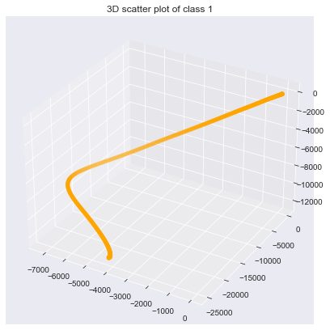

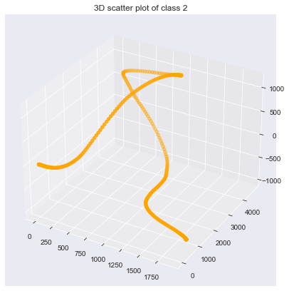

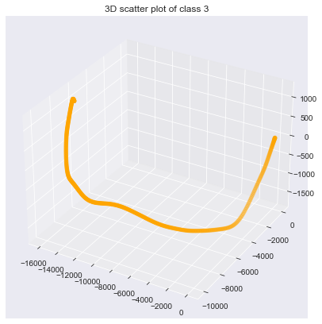

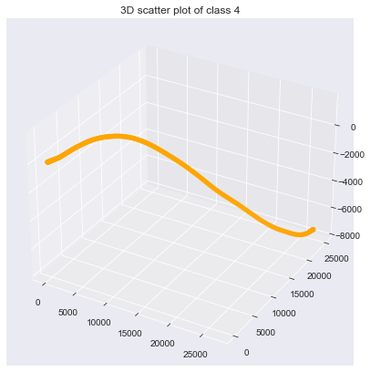

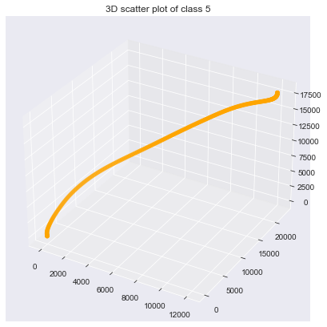

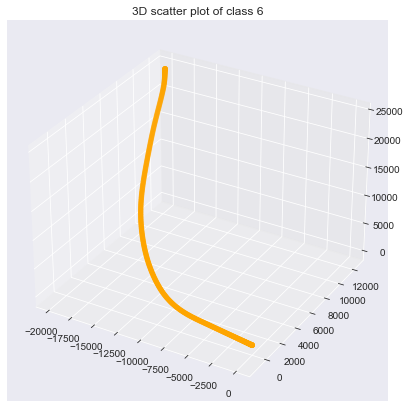

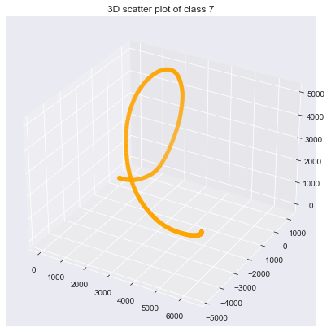

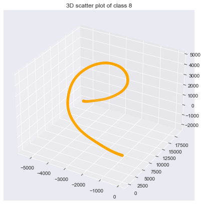

```python
for i in range(1,9):
    Same_class_observations=X_train.loc[X_train.iloc[:,1]==i]
    sample=Same_class_observations.sample()

    x=X_train.loc[sample.iloc[0,0]][2:]
    y=Y_train.loc[sample.iloc[0,0]][2:]
    z=Z_train.loc[sample.iloc[0,0]][2:]

    # Creating figure
    fig = plt.figure(figsize = (10, 7))
    ax = plt.axes(projection ="3d")

    # Creating plot
    ax.scatter3D(x, y, z, color = "orange")
    #plt.scatter(x,z)
    plt.title('3D scatter plot of class %s' %i )

    # show plot
    plt.show()
```

*b) As you may have noticed, the data is provided as a regular data matrix (i.e. each row represents an instance and columns represent the time index of the observations). Assume that X, Y and Z variables are concatenated to obtain a single time series in an unusual way as follows:*

*concatenated series = [x1 x2 …. xT y1 y2 …. yT z1 z2 …. zT ]*

*In other words, the information from X, Y and Z axis are concatenated to obtain a single series of length 3T (each axis is represented by a time series of length T).*

*Apply PCA to the time series from each class in the training data. You are expected to filter the data from each class and apply PCA to the representation. Work on the following questions based on your PCA application for the time series from each class.*

• *How much variability can be recovered by the first two components?*

• *Draw the each eigenvector (component) as a time series for each class.*

*What do the eigenvectors imply in this setting? In total, you are expected to provide 8 plots. Each plot is expected to provide two time series (i.e. first eigenvector and the second eigenvector). Are there any interesting patterns/observations? If yes, provide your comments.*

```python
X_train = pd.read_csv('uWaveGestureLibrary_X_TRAIN', sep=" ", prefix="t", header=None, skipinitialspace=True)
Y_train = pd.read_csv('uWaveGestureLibrary_Y_TRAIN', sep=" ", prefix="t", header=None, skipinitialspace=True)
Z_train = pd.read_csv('uWaveGestureLibrary_Z_TRAIN', sep=" ", prefix="t", header=None, skipinitialspace=True)

df = pd.DataFrame(columns = ['time series id','time index','X','Y','Z','class'] )
newdf=df

for i in range(0,len(X_train)):
    newdf['X']=X_train.iloc[i,1:]
    newdf['Y']=Y_train.iloc[i,1:]
    newdf['Z']=Z_train.iloc[i,1:]
    newdf['time index'] = range(1,316)
    newdf['time series id'] = i+1
    newdf['class'] = X_train.iloc[i,0]
    df=pd.concat([df, newdf], axis=0, sort=False)

df=df.iloc[315:,:]
df.head(10)
```

|  | time series id | time index | X | Y | Z | class |
| --- | --- | --- | --- | --- | --- | --- |
| t1 | 1 | 1 | -0.304243 | -2.119396 | -1.528965 | 6.0 |
| t2 | 1 | 2 | -0.304243 | -2.119396 | -1.528965 | 6.0 |
| t3 | 1 | 3 | -0.304243 | -2.119396 | -1.528965 | 6.0 |
| t4 | 1 | 4 | -0.304243 | -2.119396 | -1.528965 | 6.0 |
| t5 | 1 | 5 | -0.304243 | -2.119396 | -1.528965 | 6.0 |
| t6 | 1 | 6 | -0.304243 | -2.119396 | -1.528965 | 6.0 |
| t7 | 1 | 7 | -0.304243 | -2.119396 | -1.528965 | 6.0 |
| t8 | 1 | 8 | -0.304243 | -2.119396 | -1.528965 | 6.0 |
| t9 | 1 | 9 | -0.304243 | -2.119396 | -1.528965 | 6.0 |
| t10 | 1 | 10 | -0.304243 | -2.119396 | -1.528965 | 6.0 |

```python
features = ['X', 'Y', 'Z']
x = df.loc[:, features].values
pca = PCA(n_components=1)
principalComponents = pca.fit_transform(x)
principalDf = pd.DataFrame(data = principalComponents, columns = ['principal component 1'])
explained_variance = pca.explained_variance_ratio_
print(principalDf)
explained_variance
```

```
        principal component 1
0                   -2.492575
1                   -2.492575
2                   -2.492575
3                   -2.492575
4                   -2.492575
...                       ...
282235              -0.262244
282236              -0.177775
282237              -0.132596
282238              -0.110094
282239              -0.087592

[282240 rows x 1 columns]
```

```
array([0.49059498])
```

```python
finalDf=principalDf.join(df['time series id'].reset_index())
del finalDf['index']
finalDf=finalDf.join(df['class'].reset_index())
del finalDf['index']
finalDf
```

|  | principal component 1 | time series id | class |
| --- | --- | --- | --- |
| 0 | -2.492575 | 1 | 6.0 |
| 1 | -2.492575 | 1 | 6.0 |
| 2 | -2.492575 | 1 | 6.0 |
| 3 | -2.492575 | 1 | 6.0 |
| 4 | -2.492575 | 1 | 6.0 |
| ... | ... | ... | ... |
| 282235 | -0.262244 | 896 | 5.0 |
| 282236 | -0.177775 | 896 | 5.0 |
| 282237 | -0.132596 | 896 | 5.0 |
| 282238 | -0.110094 | 896 | 5.0 |
| 282239 | -0.087592 | 896 | 5.0 |

282240 rows × 3 columns

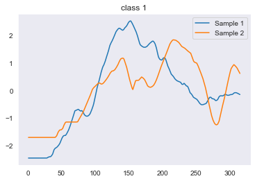

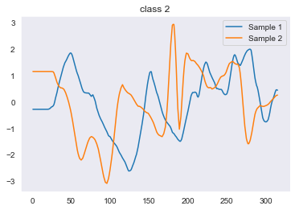

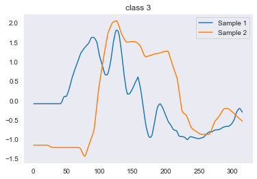

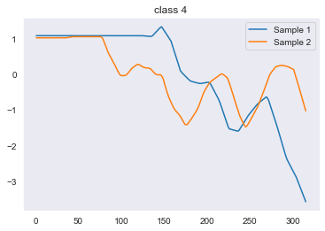

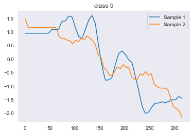

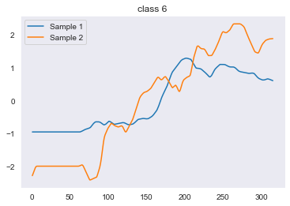

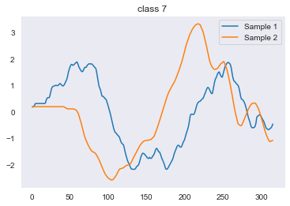

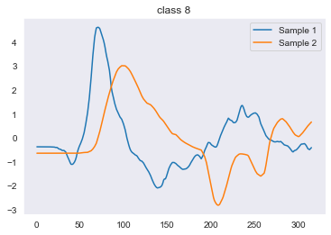

```python
for i in range(1,9):
    same_class_observations=finalDf.loc[finalDf.iloc[:,2]==i]
    samples=same_class_observations['time series id'].sample(n=2).to_frame()
    rslt_df1 = finalDf[finalDf['time series id'] == samples.iloc[0,0]]
    rslt_df2 = finalDf[finalDf['time series id'] == samples.iloc[1,0]]

    plt.plot(newdf['time index'], rslt_df1.iloc[:,0])
    plt.plot(newdf['time index'], rslt_df2.iloc[:,0])
    plt.legend(["Sample 1", "Sample 2"])
    plt.title('class %s' %i)
    plt.show()
```